# Project: Investigate a European Soccer Database

**[Europe Soccer Database Link](https://www.kaggle.com/hugomathien/soccer)**

- Introduction
- Data Wrangling
- Exploratory Data Analysis
- Conclusions

## Introduction

This database is about Europe Soccer statistics on teams and players. will look first on the most preferred feet among players. after that, will search teams and matches to find the most seccussiful teams and where do teams win more

```python
import pandas as pd
import numpy as np
import matplotlib.pyplot as plt
%matplotlib inline
import seaborn as sns
import sqlite3
```

## Data Wrangling

### create SQL connection

```python
#create SQL connection to read the database
db = sqlite3.connect("database.sqlite")
```

```python
# define function to read database
def read_table(query):
    table = pd.read_sql_query(query, db)
    return table
```

### List of tables

```python
tables = read_table("""SELECT *
                        FROM sqlite_master
                        WHERE type='table';""")

tables
```

|  | type | name | tbl_name | rootpage | sql |
| --- | --- | --- | --- | --- | --- |
| 0 | table | sqlite_sequence | sqlite_sequence | 4 | CREATE TABLE sqlite_sequence(name,seq) |
| 1 | table | Player_Attributes | Player_Attributes | 11 | CREATE TABLE "Player_Attributes" (\n\t`id`\tIN... |
| 2 | table | Player | Player | 14 | CREATE TABLE `Player` (\n\t`id`\tINTEGER PRIMA... |
| 3 | table | Match | Match | 18 | CREATE TABLE `Match` (\n\t`id`\tINTEGER PRIMAR... |
| 4 | table | League | League | 24 | CREATE TABLE `League` (\n\t`id`\tINTEGER PRIMA... |
| 5 | table | Country | Country | 26 | CREATE TABLE `Country` (\n\t`id`\tINTEGER PRIM... |
| 6 | table | Team | Team | 29 | CREATE TABLE "Team" (\n\t`id`\tINTEGER PRIMARY... |
| 7 | table | Team_Attributes | Team_Attributes | 2 | CREATE TABLE `Team_Attributes` (\n\t`id`\tINTE... |

Previous table shows that this database has 8 tables as listed above

### Load and Investigate Datas

```python
# read country table using sql read_sql_query function
ct = read_table("SELECT * from Country")
print(ct.head())
ct.dtypes
```

```
      id     name
0      1  Belgium
1   1729  England
2   4769   France
3   7809  Germany
4  10257    Italy
```

```
id       int64
name    object
dtype: object
```

Country table has country names and a unique id for each country

```python
# read league table

lg = read_table("SELECT * from League")
print(lg.head())
lg.dtypes
```

```
      id  country_id                    name
0      1           1  Belgium Jupiler League
1   1729        1729  England Premier League
2   4769        4769          France Ligue 1
3   7809        7809   Germany 1. Bundesliga
4  10257       10257           Italy Serie A
```

```
id             int64
country_id     int64
name          object
dtype: object
```

League table has country id from country table and league name and unique id for each league

```python
# read Match table
mt = read_table("SELECT * from Match")
print(mt.head())
mt.dtypes
```

```
   id  country_id  league_id     season  stage                 date  \
0   1           1          1  2008/2009      1  2008-08-17 00:00:00
1   2           1          1  2008/2009      1  2008-08-16 00:00:00
2   3           1          1  2008/2009      1  2008-08-16 00:00:00
3   4           1          1  2008/2009      1  2008-08-17 00:00:00
4   5           1          1  2008/2009      1  2008-08-16 00:00:00

   match_api_id  home_team_api_id  away_team_api_id  home_team_goal  ...  \
0        492473              9987              9993               1  ...
1        492474             10000              9994               0  ...
2        492475              9984              8635               0  ...
3        492476              9991              9998               5  ...
4        492477              7947              9985               1  ...

    SJA   VCH   VCD   VCA   GBH   GBD   GBA   BSH   BSD   BSA
0  4.00  1.65  3.40  4.50  1.78  3.25  4.00  1.73  3.40  4.20
1  3.80  2.00  3.25  3.25  1.85  3.25  3.75  1.91  3.25  3.60
2  2.50  2.35  3.25  2.65  2.50  3.20  2.50  2.30  3.20  2.75
3  7.50  1.45  3.75  6.50  1.50  3.75  5.50  1.44  3.75  6.50
4  1.73  4.50  3.40  1.65  4.50  3.50  1.65  4.75  3.30  1.67

[5 rows x 115 columns]
```

```
id                    int64
country_id            int64
league_id             int64
season               object
stage                 int64
date                 object
match_api_id          int64
home_team_api_id      int64
away_team_api_id      int64
home_team_goal        int64
away_team_goal        int64
home_player_X1      float64
home_player_X2      float64
home_player_X3      float64
home_player_X4      float64
home_player_X5      float64
home_player_X6      float64
home_player_X7      float64
home_player_X8      float64
home_player_X9      float64
home_player_X10     float64
home_player_X11     float64
away_player_X1      float64
away_player_X2      float64
away_player_X3      float64
away_player_X4      float64
away_player_X5      float64
away_player_X6      float64
away_player_X7      float64
away_player_X8      float64
                     ...
B365H               float64
B365D               float64
B365A               float64
BWH                 float64
BWD                 float64
BWA                 float64
IWH                 float64
IWD                 float64
IWA                 float64
LBH                 float64
LBD                 float64
LBA                 float64
PSH                 float64
PSD                 float64
PSA                 float64
WHH                 float64
WHD                 float64
WHA                 float64
SJH                 float64
SJD                 float64
SJA                 float64
VCH                 float64
VCD                 float64
VCA                 float64
GBH                 float64
GBD                 float64
GBA                 float64
BSH                 float64
BSD                 float64
BSA                 float64
Length: 115, dtype: object
```

Match table has unique id for each match and has statistics about matches as season, date and number of goals for each team

```python
# read Player table
pl = read_table("SELECT * from Player")
print(pl.head())
pl.dtypes
```

```
   id  player_api_id         player_name  player_fifa_api_id  \
0   1         505942  Aaron Appindangoye              218353
1   2         155782     Aaron Cresswell              189615
2   3         162549         Aaron Doran              186170
3   4          30572       Aaron Galindo              140161
4   5          23780        Aaron Hughes               17725

              birthday  height  weight
0  1992-02-29 00:00:00  182.88     187
1  1989-12-15 00:00:00  170.18     146
2  1991-05-13 00:00:00  170.18     163
3  1982-05-08 00:00:00  182.88     198
4  1979-11-08 00:00:00  182.88     154
```

```
id                      int64
player_api_id           int64
player_name            object
player_fifa_api_id      int64
birthday               object
height                float64
weight                  int64
dtype: object
```

Player table has unique id for each player and has statistics about players as name, birthday, weight and height

```python
# read Player Attributes table
pla = read_table("SELECT * from Player_Attributes")
print(pla.head())
pla.dtypes
```

```
   id  player_fifa_api_id  player_api_id                 date  overall_rating  \
0   1              218353         505942  2016-02-18 00:00:00            67.0
1   2              218353         505942  2015-11-19 00:00:00            67.0
2   3              218353         505942  2015-09-21 00:00:00            62.0
3   4              218353         505942  2015-03-20 00:00:00            61.0
4   5              218353         505942  2007-02-22 00:00:00            61.0

   potential preferred_foot attacking_work_rate defensive_work_rate  crossing  \
0       71.0          right              medium              medium      49.0
1       71.0          right              medium              medium      49.0
2       66.0          right              medium              medium      49.0
3       65.0          right              medium              medium      48.0
4       65.0          right              medium              medium      48.0

   ...  vision  penalties  marking  standing_tackle  sliding_tackle  \
0  ...    54.0       48.0     65.0             69.0            69.0
1  ...    54.0       48.0     65.0             69.0            69.0
2  ...    54.0       48.0     65.0             66.0            69.0
3  ...    53.0       47.0     62.0             63.0            66.0
4  ...    53.0       47.0     62.0             63.0            66.0

   gk_diving  gk_handling  gk_kicking  gk_positioning  gk_reflexes
0        6.0         11.0        10.0             8.0          8.0
1        6.0         11.0        10.0             8.0          8.0
2        6.0         11.0        10.0             8.0          8.0
3        5.0         10.0         9.0             7.0          7.0
4        5.0         10.0         9.0             7.0          7.0

[5 rows x 42 columns]
```

```
id                       int64
player_fifa_api_id       int64
player_api_id            int64
date                    object
overall_rating         float64
potential              float64
preferred_foot          object
attacking_work_rate     object
defensive_work_rate     object
crossing               float64
finishing              float64
heading_accuracy       float64
short_passing          float64
volleys                float64
dribbling              float64
curve                  float64
free_kick_accuracy     float64
long_passing           float64
ball_control           float64
acceleration           float64
sprint_speed           float64
agility                float64
reactions              float64
balance                float64
shot_power             float64
jumping                float64
stamina                float64
strength               float64
long_shots             float64
aggression             float64
interceptions          float64
positioning            float64
vision                 float64
penalties              float64
marking                float64
standing_tackle        float64
sliding_tackle         float64
gk_diving              float64
gk_handling            float64
gk_kicking             float64
gk_positioning         float64
gk_reflexes            float64
dtype: object
```

Player Attributes table has player attributes in each season as preferred feet, rating and potential

```python
# read Team table
tm = read_table("SELECT * from Team")
print(tm.head())
tm.dtypes
```

```
   id  team_api_id  team_fifa_api_id     team_long_name team_short_name
0   1         9987             673.0           KRC Genk             GEN
1   2         9993             675.0       Beerschot AC             BAC
2   3        10000           15005.0   SV Zulte-Waregem             ZUL
3   4         9994            2007.0   Sporting Lokeren             LOK
4   5         9984            1750.0  KSV Cercle Brugge             CEB
```

```
id                    int64
team_api_id           int64
team_fifa_api_id    float64
team_long_name       object
team_short_name      object
dtype: object
```

Team table has teams long and short names along with team's fifa id

```python
# read Team Attributes table
tma = read_table("SELECT * from Team_Attributes")
print(tma.head())
tma.dtypes
```

```
   id  team_fifa_api_id  team_api_id                 date  buildUpPlaySpeed  \
0   1               434         9930  2010-02-22 00:00:00                60
1   2               434         9930  2014-09-19 00:00:00                52
2   3               434         9930  2015-09-10 00:00:00                47
3   4                77         8485  2010-02-22 00:00:00                70
4   5                77         8485  2011-02-22 00:00:00                47

  buildUpPlaySpeedClass  buildUpPlayDribbling buildUpPlayDribblingClass  \
0              Balanced                   NaN                    Little
1              Balanced                  48.0                    Normal
2              Balanced                  41.0                    Normal
3                  Fast                   NaN                    Little
4              Balanced                   NaN                    Little

   buildUpPlayPassing buildUpPlayPassingClass  ... chanceCreationShooting  \
```

[output cut: 35 more lines]

```
id                                  int64
team_fifa_api_id                    int64
team_api_id                         int64
date                               object
buildUpPlaySpeed                    int64
buildUpPlaySpeedClass              object
buildUpPlayDribbling              float64
buildUpPlayDribblingClass          object
buildUpPlayPassing                  int64
buildUpPlayPassingClass            object
buildUpPlayPositioningClass        object
chanceCreationPassing               int64
chanceCreationPassingClass         object
chanceCreationCrossing              int64
chanceCreationCrossingClass        object
chanceCreationShooting              int64
chanceCreationShootingClass        object
chanceCreationPositioningClass     object
defencePressure                     int64
defencePressureClass               object
defenceAggression                   int64
defenceAggressionClass             object
defenceTeamWidth                    int64
defenceTeamWidthClass              object
defenceDefenderLineClass           object
dtype: object
```

```python
# read sqlite sequence table
ss = read_table("SELECT * from sqlite_sequence")
print(ss.head())
ss.dtypes
```

```
      name     seq
0     Team  103916
1  Country   51958
2   League   51958
3    Match   51958
4   Player   11075
```

```
name    object
seq      int64
dtype: object
```

### Findings

- From the previous queries, we can see that date colums in match, player_attribute and team_attribute tables and birthday column in player have incorrect type, object rather than datetime. Thus, we need to convert all the previous column to datetime type
- sqlite_sequence table will be ignored since it doesn't represent any important data

### Data Cleaning

##### Data Conversion

```python
# to change columns type to datetime, will use to_datetime() function in panda library

mt['date'] = pd.to_datetime(mt['date'])
mt.dtypes

pl['birthday'] = pd.to_datetime(pl['birthday'])
pl.dtypes

pla['date'] = pd.to_datetime(pla['date'])
pla.dtypes

tma['date'] = pd.to_datetime(tma['date'])
```

```python
#check for columns type after conversion wether it's been converted successfully or not

print(mt['date'].dtypes)
print(pl['birthday'].dtypes)
print(pla['date'].dtypes)
print(tma['date'].dtypes)
```

```
datetime64[ns]
datetime64[ns]
datetime64[ns]
datetime64[ns]
```

#### Drop null values

##### Player Attributes Tables

```python
# will drop any record that has null value in most of its attributes
print('Before cleaning:')
print(pla.shape)
```

```
Before cleaning:
(183978, 42)
```

```python
pla = pla[pla.overall_rating >= 0 ]
print('After cleaning:')
print(pla.shape)
```

```
After cleaning:
(183142, 42)
```

After cleaning the data, we're ready to work on tables

## Explore Database

Now, will run some queries to display some information

```python
# Name of country with its league
a = read_table("SELECT ct.name, lg.name FROM Country ct, League lg ON ct.id = lg.country_id")
a
```

|  | name | name |
| --- | --- | --- |
| 0 | Belgium | Belgium Jupiler League |
| 1 | England | England Premier League |
| 2 | France | France Ligue 1 |
| 3 | Germany | Germany 1. Bundesliga |
| 4 | Italy | Italy Serie A |
| 5 | Netherlands | Netherlands Eredivisie |
| 6 | Poland | Poland Ekstraklasa |
| 7 | Portugal | Portugal Liga ZON Sagres |
| 8 | Scotland | Scotland Premier League |
| 9 | Spain | Spain LIGA BBVA |
| 10 | Switzerland | Switzerland Super League |

As per previous results, this database shows details of one league in each country, 11 leagues in total

```python
# Name of players and basic atttributes

p = read_table("""
SELECT pl.player_api_id,
    pl.player_name,
    pl.height,
    pl.weight,
    pla.preferred_foot
FROM
    player pl,
    Player_Attributes pla
ON
    pl.player_api_id = pla.player_api_id
GROUP BY
    pl.player_api_id
ORDER BY
    pl.player_name""")

p
```

|  | player_api_id | player_name | height | weight | preferred_foot |
| --- | --- | --- | --- | --- | --- |
| 0 | 505942 | Aaron Appindangoye | 182.88 | 187 | right |
| 1 | 155782 | Aaron Cresswell | 170.18 | 146 | left |
| 2 | 162549 | Aaron Doran | 170.18 | 163 | right |
| 3 | 30572 | Aaron Galindo | 182.88 | 198 | right |
| 4 | 23780 | Aaron Hughes | 182.88 | 154 | right |
| 5 | 27316 | Aaron Hunt | 182.88 | 161 | left |
| 6 | 564793 | Aaron Kuhl | 172.72 | 146 | right |
| 7 | 30895 | Aaron Lennon | 165.10 | 139 | right |
| 8 | 528212 | Aaron Lennox | 190.50 | 181 | right |
| 9 | 101042 | Aaron Meijers | 175.26 | 170 | left |
| 10 | 23889 | Aaron Mokoena | 182.88 | 181 | right |
| 11 | 231592 | Aaron Mooy | 175.26 | 150 | right |
| 12 | 163222 | Aaron Muirhead | 187.96 | 168 | right |
| 13 | 40719 | Aaron Niguez | 170.18 | 143 | left |
| 14 | 75489 | Aaron Ramsey | 177.80 | 154 | right |
| 15 | 597948 | Aaron Splaine | 172.72 | 163 | left |
| 16 | 161644 | Aaron Taylor-Sinclair | 182.88 | 176 | left |
| 17 | 23499 | Aaron Wilbraham | 190.50 | 159 | right |
| 18 | 120919 | Aatif Chahechouhe | 175.26 | 150 | right |
| 19 | 46447 | Abasse Ba | 187.96 | 185 | right |
| 20 | 167027 | Abdelaziz Barrada | 177.80 | 161 | right |
| 21 | 245653 | Abdelfettah Boukhriss | 185.42 | 161 | left |
| 22 | 128456 | Abdelhamid El Kaoutari | 180.34 | 161 | left |
| 23 | 42664 | Abdelkader Ghezzal | 182.88 | 172 | right |
| 24 | 425950 | Abdellah Zoubir | 180.34 | 161 | right |
| 25 | 38423 | Abdelmajid Oulmers | 172.72 | 143 | right |
| 26 | 3264 | Abdelmalek Cherrad | 185.42 | 165 | right |
| 27 | 467485 | Abdelmalek El Hasnaoui | 180.34 | 159 | left |
| 28 | 306735 | Abdelouahed Chakhsi | 182.88 | 170 | right |
| 29 | 41659 | Abderrazak Jadid | 177.80 | 157 | right |
| ... | ... | ... | ... | ... | ... |
| 11030 | 290868 | Zhi-Gin Lam | 175.26 | 146 | right |
| 11031 | 169594 | Zie Diabate | 177.80 | 143 | left |
| 11032 | 244953 | Ziggy Gordon | 180.34 | 170 | right |
| 11033 | 200607 | Ziguy Badibanga | 172.72 | 154 | right |
| 11034 | 642618 | Zinedine Machach | 185.42 | 163 | right |
| 11035 | 277772 | Zinho Gano | 198.12 | 205 | left |
| 11036 | 246332 | Ziri Hammar | 180.34 | 163 | right |
| 11037 | 532766 | Zizo | 175.26 | 148 | right |
| 11038 | 27305 | Zlatan Bajramovic | 182.88 | 174 | right |
| 11039 | 35724 | Zlatan Ibrahimovic | 195.58 | 209 | right |
| 11040 | 12574 | Zlatan Ljubijankic | 185.42 | 176 | right |
| 11041 | 39494 | Zlatko Dedic | 182.88 | 170 | right |
| 11042 | 17233 | Zlatko Janjic | 187.96 | 183 | right |
| 11043 | 42860 | Zlatko Junuzovic | 172.72 | 152 | right |
| 11044 | 37128 | Zola Matumona | 165.10 | 143 | left |
| 11045 | 24737 | Zoltan Gera | 182.88 | 165 | right |
| 11046 | 107281 | Zoltan Stieber | 175.26 | 148 | left |
| 11047 | 39801 | Zoltan Szelesi | 182.88 | 176 | right |
| 11048 | 491794 | Zoran Josipovic | 187.96 | 165 | right |
| 11049 | 56929 | Zoran Rendulic | 190.50 | 179 | left |
| 11050 | 99031 | Zoran Tosic | 170.18 | 157 | left |
| 11051 | 192132 | Zouhaier Dhaouadhi | 180.34 | 159 | left |
| 11052 | 282473 | Zouhair Feddal | 190.50 | 172 | left |
| 11053 | 26357 | Zoumana Camara | 182.88 | 168 | right |
| 11054 | 111182 | Zsolt Laczko | 182.88 | 176 | left |
| 11055 | 36491 | Zsolt Low | 180.34 | 154 | left |
| 11056 | 35506 | Zurab Khizanishvili | 185.42 | 172 | right |
| 11057 | 39902 | Zvjezdan Misimovic | 180.34 | 176 | right |
| 11058 | 11833 | de Oliveira Cleber Monteiro | 182.88 | 170 | right |
| 11059 | 38804 | dos Santos Fabio Junior | 175.26 | 174 | left |

11060 rows × 5 columns

We've number of 11060 players in this tables

## Exploratory Data Analysis

### Some Basic statistics

##### Most Preferred feet

```
  player_feet  feet
0        left  2687
1       right  8373
```

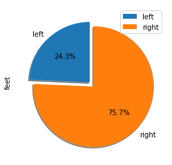

```python
# The following information shows how many players used each feet
# will join player and player attributes tables to in one table to count how many players

ft = read_table("""
SELECT player_feet, count(*) AS feet
  FROM (
    SELECT pl.player_api_id AS player_id,
        pl.player_name AS player_name,
        pl.height AS player_height,
        pl.weight AS player_weight,
        pla.preferred_foot AS player_feet
    FROM
        player pl,
        Player_Attributes pla
    ON
        pl.player_api_id = pla.player_api_id
    GROUP BY
        pl.player_api_id
    ORDER BY
        pl.player_name)
    GROUP BY
        player_feet""")
print(ft)
ft.plot.pie( 'feet' , explode = (0 , 0.1), labels= ft.player_feet, startangle=90, shadow = True, autopct='%1.1f%%')
plt.show()
```

From previous results, we see that most players use the right feet 3x more than left feet

#### Most matched played in one day

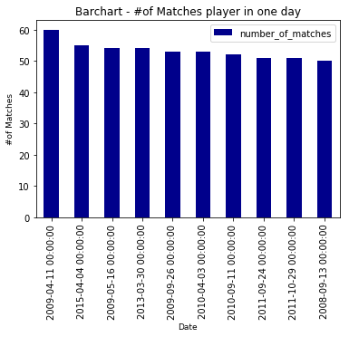

```python
match_day = read_table("""
SELECT count(*) AS number_of_matches, mt.date AS date
  FROM match mt
 GROUP BY mt.date
 ORDER BY number_of_matches DESC
 LIMIT 10
 """)
plt.figure()
ax = match_day.plot.bar( x='date', y='number_of_matches', rot=90, color='darkblue');
plt.xlabel('Date', fontsize=9)
plt.ylabel('#of Matches', fontsize=9)
plt.title('Barchart - #of Matches player in one day',fontsize=12)
```

As shows, the most played matches in one day was on 11th of April 2009 with 60 matches. following is the matches information

```python
s = read_table("""
SELECT mt.date AS date, mt.id AS match_id, mt.season AS season, lg.name AS league_name, tm1.team_long_name AS home_team, tm2.team_long_name AS away_team,
	   (mt.home_team_goal+mt.away_team_goal) As number_of_goals
  FROM country ct,
   league lg,
   Match mt,
   Team tm1,
   Team tm2
    ON mt.country_id = ct.id AND mt.league_id = lg.id AND mt.home_team_api_id = tm1.team_api_id AND mt.away_team_api_id = tm2.team_api_id
 WHERE date = '2009-04-11 00:00:00'
 ORDER BY match_id
  """)
s
```

|  | date | match_id | season | league_name | home_team | away_team | number_of_goals |
| --- | --- | --- | --- | --- | --- | --- | --- |
| 0 | 2009-04-11 00:00:00 | 192 | 2008/2009 | Belgium Jupiler League | Beerschot AC | SV Zulte-Waregem | 3 |
| 1 | 2009-04-11 00:00:00 | 193 | 2008/2009 | Belgium Jupiler League | Standard de Liège | Sporting Lokeren | 1 |
| 2 | 2009-04-11 00:00:00 | 194 | 2008/2009 | Belgium Jupiler League | KV Kortrijk | FCV Dender EH | 3 |
| 3 | 2009-04-11 00:00:00 | 195 | 2008/2009 | Belgium Jupiler League | RAEC Mons | KV Mechelen | 1 |
| 4 | 2009-04-11 00:00:00 | 196 | 2008/2009 | Belgium Jupiler League | Sporting Charleroi | Royal Excel Mouscron | 1 |
| 5 | 2009-04-11 00:00:00 | 197 | 2008/2009 | Belgium Jupiler League | KSV Cercle Brugge | Tubize | 5 |
| 6 | 2009-04-11 00:00:00 | 1979 | 2008/2009 | England Premier League | Liverpool | Blackburn Rovers | 4 |
| 7 | 2009-04-11 00:00:00 | 1980 | 2008/2009 | England Premier League | Sunderland | Manchester United | 3 |
| 8 | 2009-04-11 00:00:00 | 1981 | 2008/2009 | England Premier League | Tottenham Hotspur | West Ham United | 1 |
| 9 | 2009-04-11 00:00:00 | 1983 | 2008/2009 | England Premier League | Middlesbrough | Hull City | 4 |
| 10 | 2009-04-11 00:00:00 | 1985 | 2008/2009 | England Premier League | Portsmouth | West Bromwich Albion | 4 |
| 11 | 2009-04-11 00:00:00 | 1986 | 2008/2009 | England Premier League | Stoke City | Newcastle United | 2 |
| 12 | 2009-04-11 00:00:00 | 1987 | 2008/2009 | England Premier League | Wigan Athletic | Arsenal | 5 |
| 13 | 2009-04-11 00:00:00 | 1988 | 2008/2009 | England Premier League | Chelsea | Bolton Wanderers | 7 |
| 14 | 2009-04-11 00:00:00 | 5009 | 2008/2009 | France Ligue 1 | AJ Auxerre | Girondins de Bordeaux | 2 |
| 15 | 2009-04-11 00:00:00 | 5010 | 2008/2009 | France Ligue 1 | Le Havre AC | SM Caen | 3 |
| 16 | 2009-04-11 00:00:00 | 5011 | 2008/2009 | France Ligue 1 | Le Mans FC | FC Sochaux-Montbéliard | 2 |
| 17 | 2009-04-11 00:00:00 | 5015 | 2008/2009 | France Ligue 1 | AS Nancy-Lorraine | Valenciennes FC | 2 |
| 18 | 2009-04-11 00:00:00 | 5016 | 2008/2009 | France Ligue 1 | OGC Nice | FC Lorient | 2 |
| 19 | 2009-04-11 00:00:00 | 5017 | 2008/2009 | France Ligue 1 | Stade Rennais FC | AS Saint-Étienne | 1 |
| 20 | 2009-04-11 00:00:00 | 5018 | 2008/2009 | France Ligue 1 | Toulouse FC | FC Nantes | 1 |
| 21 | 2009-04-11 00:00:00 | 7980 | 2008/2009 | Germany 1. Bundesliga | FC Bayern Munich | Eintracht Frankfurt | 4 |
| 22 | 2009-04-11 00:00:00 | 7982 | 2008/2009 | Germany 1. Bundesliga | Borussia Dortmund | 1. FC Köln | 4 |
| 23 | 2009-04-11 00:00:00 | 7984 | 2008/2009 | Germany 1. Bundesliga | FC Schalke 04 | Karlsruher SC | 2 |
| 24 | 2009-04-11 00:00:00 | 7985 | 2008/2009 | Germany 1. Bundesliga | FC Energie Cottbus | DSC Arminia Bielefeld | 3 |
| 25 | 2009-04-11 00:00:00 | 7986 | 2008/2009 | Germany 1. Bundesliga | Hannover 96 | Hertha BSC Berlin | 2 |
| 26 | 2009-04-11 00:00:00 | 7987 | 2008/2009 | Germany 1. Bundesliga | Borussia Mönchengladbach | VfL Wolfsburg | 3 |
| 27 | 2009-04-11 00:00:00 | 7988 | 2008/2009 | Germany 1. Bundesliga | TSG 1899 Hoffenheim | VfL Bochum | 3 |
| 28 | 2009-04-11 00:00:00 | 10497 | 2008/2009 | Italy Serie A | Lazio | Roma | 6 |
| 29 | 2009-04-11 00:00:00 | 10498 | 2008/2009 | Italy Serie A | Bologna | Siena | 5 |
| 30 | 2009-04-11 00:00:00 | 10500 | 2008/2009 | Italy Serie A | Chievo Verona | Milan | 1 |
| 31 | 2009-04-11 00:00:00 | 10501 | 2008/2009 | Italy Serie A | Genoa | Juventus | 5 |
| 32 | 2009-04-11 00:00:00 | 10502 | 2008/2009 | Italy Serie A | Inter | Palermo | 4 |
| 33 | 2009-04-11 00:00:00 | 10503 | 2008/2009 | Italy Serie A | Torino | Catania | 3 |
| 34 | 2009-04-11 00:00:00 | 10504 | 2008/2009 | Italy Serie A | Fiorentina | Cagliari | 3 |
| 35 | 2009-04-11 00:00:00 | 10505 | 2008/2009 | Italy Serie A | Napoli | Atalanta | 0 |
| 36 | 2009-04-11 00:00:00 | 10506 | 2008/2009 | Italy Serie A | Lecce | Sampdoria | 4 |
| 37 | 2009-04-11 00:00:00 | 13482 | 2008/2009 | Netherlands Eredivisie | De Graafschap | N.E.C. | 4 |
| 38 | 2009-04-11 00:00:00 | 13483 | 2008/2009 | Netherlands Eredivisie | ADO Den Haag | Sparta Rotterdam | 3 |
| 39 | 2009-04-11 00:00:00 | 13484 | 2008/2009 | Netherlands Eredivisie | PSV | FC Utrecht | 2 |
| 40 | 2009-04-11 00:00:00 | 13485 | 2008/2009 | Netherlands Eredivisie | FC Twente | Roda JC Kerkrade | 6 |
| 41 | 2009-04-11 00:00:00 | 15842 | 2008/2009 | Poland Ekstraklasa | Piast Gliwice | Lech Poznań | 3 |
| 42 | 2009-04-11 00:00:00 | 15845 | 2008/2009 | Poland Ekstraklasa | Ruch Chorzów | P. Warszawa | 4 |
| 43 | 2009-04-11 00:00:00 | 15846 | 2008/2009 | Poland Ekstraklasa | Wisła Kraków | Jagiellonia Białystok | 1 |
| 44 | 2009-04-11 00:00:00 | 15847 | 2008/2009 | Poland Ekstraklasa | Legia Warszawa | Cracovia | 4 |
| 45 | 2009-04-11 00:00:00 | 15849 | 2008/2009 | Poland Ekstraklasa | Lechia Gdańsk | GKS Bełchatów | 3 |
| 46 | 2009-04-11 00:00:00 | 17770 | 2008/2009 | Portugal Liga ZON Sagres | FC Porto | Amadora | 3 |
| 47 | 2009-04-11 00:00:00 | 17771 | 2008/2009 | Portugal Liga ZON Sagres | Sporting CP | Naval 1° de Maio | 4 |
| 48 | 2009-04-11 00:00:00 | 17772 | 2008/2009 | Portugal Liga ZON Sagres | SL Benfica | Académica de Coimbra | 1 |
| 49 | 2009-04-11 00:00:00 | 17774 | 2008/2009 | Portugal Liga ZON Sagres | CF Os Belenenses | Vitória Setúbal | 3 |
| 50 | 2009-04-11 00:00:00 | 17776 | 2008/2009 | Portugal Liga ZON Sagres | Leixões SC | Rio Ave FC | 1 |
| 51 | 2009-04-11 00:00:00 | 19844 | 2008/2009 | Scotland Premier League | Rangers | Motherwell | 4 |
| 52 | 2009-04-11 00:00:00 | 19845 | 2008/2009 | Scotland Premier League | Heart of Midlothian | Celtic | 2 |
| 53 | 2009-04-11 00:00:00 | 19846 | 2008/2009 | Scotland Premier League | Kilmarnock | Falkirk | 3 |
| 54 | 2009-04-11 00:00:00 | 19847 | 2008/2009 | Scotland Premier League | Aberdeen | Inverness Caledonian Thistle | 1 |
| 55 | 2009-04-11 00:00:00 | 19849 | 2008/2009 | Scotland Premier League | Hamilton Academical FC | Dundee United | 1 |
| 56 | 2009-04-11 00:00:00 | 21754 | 2008/2009 | Spain LIGA BBVA | Villarreal CF | Málaga CF | 2 |
| 57 | 2009-04-11 00:00:00 | 21756 | 2008/2009 | Spain LIGA BBVA | FC Barcelona | RC Recreativo | 2 |
| 58 | 2009-04-11 00:00:00 | 24656 | 2008/2009 | Switzerland Super League | FC Aarau | AC Bellinzona | 0 |
| 59 | 2009-04-11 00:00:00 | 24657 | 2008/2009 | Switzerland Super League | Grasshopper Club Zürich | BSC Young Boys | 6 |

The following match has the most number of goals in that day

```python
ss = read_table("""SELECT season, league_name, home_team, home_team_goal, away_team_goal, away_team,
	CASE
           WHEN home_team_goal > away_team_goal
               THEN home_team
		   WHEN away_team_goal > home_team_goal
               THEN away_team
       END Winner
FROM
(SELECT mt.date AS date, mt.id AS match_id, mt.season AS season, lg.name AS league_name, tm1.team_long_name AS home_team, mt.home_team_goal, mt.away_team_goal, tm2.team_long_name AS away_team,
	   (mt.home_team_goal+mt.away_team_goal) As number_of_goals
  FROM country ct,
   league lg,
   Match mt,
   Team tm1,
   Team tm2
    ON mt.country_id = ct.id AND mt.league_id = lg.id AND mt.home_team_api_id = tm1.team_api_id AND mt.away_team_api_id = tm2.team_api_id
 WHERE date = '2009-04-11 00:00:00'
 ORDER BY number_of_goals DESC)
LIMIT 1""")

ss
```

|  | season | league_name | home_team | home_team_goal | away_team_goal | away_team | Winner |
| --- | --- | --- | --- | --- | --- | --- | --- |
| 0 | 2008/2009 | England Premier League | Chelsea | 4 | 3 | Bolton Wanderers | Chelsea |

#### Number of Matches per season

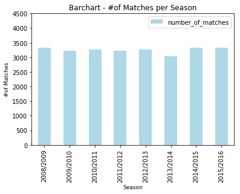

```python
match_season = read_table("""
SELECT mt.season AS season, count(*) AS number_of_matches
  FROM country ct,
   league lg,
   Match mt,
   Team tm1,
   Team tm2
    ON mt.country_id = ct.id AND mt.league_id = lg.id AND mt.home_team_api_id = tm1.team_api_id AND mt.away_team_api_id = tm2.team_api_id
 GROUP BY season
 """)
plt.figure()
match_season.plot.bar(x='season', y='number_of_matches', yticks = range(0,5000,500), color='lightblue');
plt.xlabel('Season', fontsize=9)
plt.ylabel('#of Matches', fontsize=9)
plt.title('Barchart - #of Matches per Season',fontsize=12)
plt.show()
```

### Number of Matches per season per league

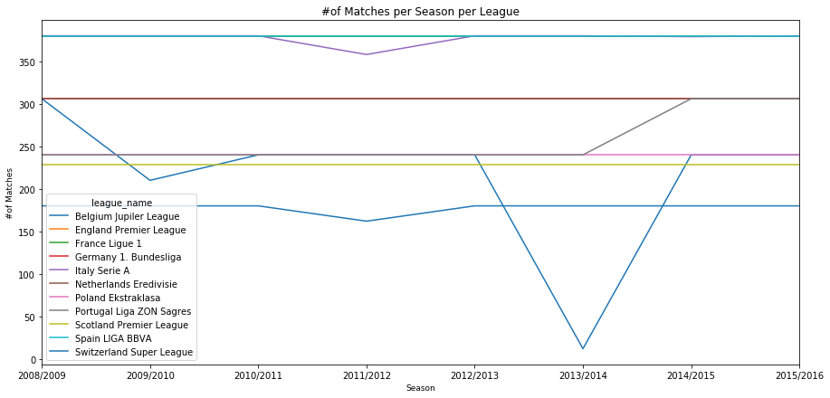

```python
msl = read_table("""
SELECT mt.season AS season, lg.name AS league_name, count(*) AS number_of_matches
  FROM country ct,
   league lg,
   Match mt,
   Team tm1,
   Team tm2
    ON mt.country_id = ct.id AND mt.league_id = lg.id AND mt.home_team_api_id = tm1.team_api_id AND mt.away_team_api_id = tm2.team_api_id
 GROUP BY season, league_name
 ORDER BY season, league_name
 """)

msl
fig, ax = plt.subplots(figsize=(15,7))
msl.groupby(['season','league_name']).sum()['number_of_matches'].unstack().plot(ax=ax)
plt.xlabel('Season', fontsize=9)
plt.ylabel('#of Matches', fontsize=9)
plt.title('#of Matches per Season per League',fontsize=12)
plt.show()
```

The graph shows that there is a huge drop in number of matches in Belgium Jupiler League for season 2013/2014 by more than 200 matches which indecate a problem with the records either there are missing records or the league has stopped playig matches for a reason

### Number of Goals per season

```python
ng = read_table("""
SELECT mt.id AS match_id, mt.season AS season, lg.name AS league_name, tm1.team_long_name AS home_team, tm2.team_long_name AS away_team,
   (mt.home_team_goal+mt.away_team_goal) As number_of_goals
  FROM country ct,
   league lg,
   Match mt,
   Team tm1,
   Team tm2
    ON mt.country_id = ct.id AND mt.league_id = lg.id AND mt.home_team_api_id = tm1.team_api_id AND mt.away_team_api_id = tm2.team_api_id
 ORDER BY match_id
  """)
ng
```

|  | match_id | season | league_name | home_team | away_team | number_of_goals |
| --- | --- | --- | --- | --- | --- | --- |
| 0 | 1 | 2008/2009 | Belgium Jupiler League | KRC Genk | Beerschot AC | 2 |
| 1 | 2 | 2008/2009 | Belgium Jupiler League | SV Zulte-Waregem | Sporting Lokeren | 0 |
| 2 | 3 | 2008/2009 | Belgium Jupiler League | KSV Cercle Brugge | RSC Anderlecht | 3 |
| 3 | 4 | 2008/2009 | Belgium Jupiler League | KAA Gent | RAEC Mons | 5 |
| 4 | 5 | 2008/2009 | Belgium Jupiler League | FCV Dender EH | Standard de Liège | 4 |
| 5 | 6 | 2008/2009 | Belgium Jupiler League | KV Mechelen | Club Brugge KV | 2 |
| 6 | 7 | 2008/2009 | Belgium Jupiler League | KSV Roeselare | KV Kortrijk | 4 |
| 7 | 8 | 2008/2009 | Belgium Jupiler League | Tubize | Royal Excel Mouscron | 3 |
| 8 | 9 | 2008/2009 | Belgium Jupiler League | KVC Westerlo | Sporting Charleroi | 1 |
| 9 | 10 | 2008/2009 | Belgium Jupiler League | Club Brugge KV | KV Kortrijk | 5 |
| 10 | 11 | 2008/2009 | Belgium Jupiler League | Standard de Liège | Sporting Charleroi | 3 |
| 11 | 12 | 2008/2009 | Belgium Jupiler League | SV Zulte-Waregem | KAA Gent | 2 |
| 12 | 13 | 2008/2009 | Belgium Jupiler League | Sporting Lokeren | RAEC Mons | 0 |
| 13 | 14 | 2008/2009 | Belgium Jupiler League | FCV Dender EH | KVC Westerlo | 4 |
| 14 | 15 | 2008/2009 | Belgium Jupiler League | KV Mechelen | KSV Roeselare | 3 |
| 15 | 16 | 2008/2009 | Belgium Jupiler League | Royal Excel Mouscron | KSV Cercle Brugge | 1 |
| 16 | 17 | 2008/2009 | Belgium Jupiler League | Tubize | KRC Genk | 4 |
| 17 | 18 | 2008/2009 | Belgium Jupiler League | Beerschot AC | RSC Anderlecht | 4 |
| 18 | 19 | 2008/2009 | Belgium Jupiler League | RSC Anderlecht | Sporting Lokeren | 5 |
| 19 | 20 | 2008/2009 | Belgium Jupiler League | RAEC Mons | Royal Excel Mouscron | 0 |
| 20 | 21 | 2008/2009 | Belgium Jupiler League | Sporting Charleroi | Club Brugge KV | 4 |
| 21 | 22 | 2008/2009 | Belgium Jupiler League | KSV Cercle Brugge | SV Zulte-Waregem | 2 |
| 22 | 23 | 2008/2009 | Belgium Jupiler League | KAA Gent | FCV Dender EH | 2 |
| 23 | 24 | 2008/2009 | Belgium Jupiler League | KSV Roeselare | Tubize | 3 |
| 24 | 25 | 2008/2009 | Belgium Jupiler League | KV Kortrijk | KV Mechelen | 0 |
| 25 | 26 | 2008/2009 | Belgium Jupiler League | KVC Westerlo | KRC Genk | 1 |
| 26 | 27 | 2008/2009 | Belgium Jupiler League | Beerschot AC | Standard de Liège | 4 |
| 27 | 28 | 2008/2009 | Belgium Jupiler League | Club Brugge KV | RSC Anderlecht | 2 |
| 28 | 29 | 2008/2009 | Belgium Jupiler League | KRC Genk | KSV Roeselare | 2 |
| 29 | 30 | 2008/2009 | Belgium Jupiler League | SV Zulte-Waregem | Beerschot AC | 4 |
| ... | ... | ... | ... | ... | ... | ... |
| 25949 | 25950 | 2015/2016 | Switzerland Super League | Grasshopper Club Zürich | Lugano | 7 |
| 25950 | 25951 | 2015/2016 | Switzerland Super League | FC Luzern | FC Basel | 4 |
| 25951 | 25952 | 2015/2016 | Switzerland Super League | FC St. Gallen | FC Zürich | 2 |
| 25952 | 25953 | 2015/2016 | Switzerland Super League | FC Vaduz | FC Sion | 2 |
| 25953 | 25954 | 2015/2016 | Switzerland Super League | BSC Young Boys | FC Thun | 4 |
| 25954 | 25955 | 2015/2016 | Switzerland Super League | FC Basel | FC Thun | 4 |
| 25955 | 25956 | 2015/2016 | Switzerland Super League | BSC Young Boys | Lugano | 1 |
| 25956 | 25957 | 2015/2016 | Switzerland Super League | FC Luzern | FC St. Gallen | 1 |
| 25957 | 25958 | 2015/2016 | Switzerland Super League | FC Sion | FC Zürich | 4 |
| 25958 | 25959 | 2015/2016 | Switzerland Super League | FC Vaduz | Grasshopper Club Zürich | 6 |
| 25959 | 25960 | 2015/2016 | Switzerland Super League | Lugano | FC Basel | 4 |
| 25960 | 25961 | 2015/2016 | Switzerland Super League | FC Sion | BSC Young Boys | 4 |
| 25961 | 25962 | 2015/2016 | Switzerland Super League | FC St. Gallen | Grasshopper Club Zürich | 2 |
| 25962 | 25963 | 2015/2016 | Switzerland Super League | FC Thun | FC Vaduz | 1 |
| 25963 | 25964 | 2015/2016 | Switzerland Super League | FC Zürich | FC Luzern | 7 |
| 25964 | 25965 | 2015/2016 | Switzerland Super League | Lugano | FC Luzern | 1 |
| 25965 | 25966 | 2015/2016 | Switzerland Super League | FC Vaduz | FC St. Gallen | 1 |
| 25966 | 25967 | 2015/2016 | Switzerland Super League | FC Thun | FC Sion | 2 |
| 25967 | 25968 | 2015/2016 | Switzerland Super League | FC Basel | FC Zürich | 4 |
| 25968 | 25969 | 2015/2016 | Switzerland Super League | Grasshopper Club Zürich | BSC Young Boys | 5 |
| 25969 | 25970 | 2015/2016 | Switzerland Super League | FC Basel | FC St. Gallen | 3 |
| 25970 | 25971 | 2015/2016 | Switzerland Super League | BSC Young Boys | FC Vaduz | 4 |
| 25971 | 25972 | 2015/2016 | Switzerland Super League | FC Luzern | Grasshopper Club Zürich | 6 |
| 25972 | 25973 | 2015/2016 | Switzerland Super League | FC Zürich | FC Thun | 6 |
| 25973 | 25974 | 2015/2016 | Switzerland Super League | FC Sion | Lugano | 3 |
| 25974 | 25975 | 2015/2016 | Switzerland Super League | FC St. Gallen | FC Thun | 1 |
| 25975 | 25976 | 2015/2016 | Switzerland Super League | FC Vaduz | FC Luzern | 3 |
| 25976 | 25977 | 2015/2016 | Switzerland Super League | Grasshopper Club Zürich | FC Sion | 2 |
| 25977 | 25978 | 2015/2016 | Switzerland Super League | Lugano | FC Zürich | 0 |
| 25978 | 25979 | 2015/2016 | Switzerland Super League | BSC Young Boys | FC Basel | 7 |

25979 rows × 6 columns

#### Number of goals per team home/away matches

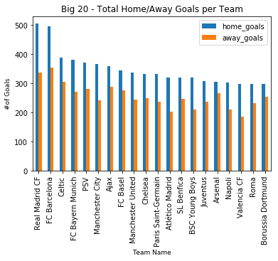

```python
goals_teams = read_table("""
SELECT t1.team_name AS team_name,
       t1.home_team_goal AS home_goals,
       t2.away_team_goal AS away_goals,
       CASE
           WHEN t1.home_team_goal > t2.away_team_goal
               THEN 'Home'
           ELSE 'Away'
       END most_goals
  FROM (
 SELECT tm1.team_long_name AS team_name, sum(mt.home_team_goal) AS home_team_goal
  FROM country ct,
   league lg,
   Match mt,
   Team tm1,
   Team tm2
    ON mt.country_id = ct.id AND mt.league_id = lg.id AND mt.home_team_api_id = tm1.team_api_id AND mt.away_team_api_id = tm2.team_api_id
 GROUP BY team_name) t1,
 ( SELECT tm2.team_long_name AS team_name, sum(mt.away_team_goal) AS away_team_goal
  FROM country ct,
   league lg,
   Match mt,
   Team tm1,
   Team tm2
    ON mt.country_id = ct.id AND mt.league_id = lg.id AND mt.home_team_api_id = tm1.team_api_id AND mt.away_team_api_id = tm2.team_api_id
 GROUP BY team_name) t2
    ON t1.team_name = t2.team_name
    ORDER BY home_goals DESC, away_goals
    LIMIT 20
      """)
plt.figure()
goals_teams.plot.bar(x='team_name', y=['home_goals','away_goals'])
plt.xlabel('Team Name', fontsize=9)
plt.ylabel('#of Goals', fontsize=9)
plt.title('Big 20 - Total Home/Away Goals per Team',fontsize=12)
plt.show()
```

The statistics show that Real Madrid is the team that scores the highest number of goals in home matches. But FC Barcelona scores the highest number of goals in away matches

#### Where most teams scores more (Home/Away Matches)

```
  most_goals  number_of_teams
0       Home              283
1       Away               13
```

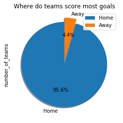

```python
ts = read_table("""
SELECT most_goals, count(*) AS number_of_teams
  FROM(
SELECT t1.team_name AS team_name,
   t1.home_team_goal AS home_goals,
 t2.away_team_goal AS away_goals,
  CASE
           WHEN t1.home_team_goal > t2.away_team_goal
               THEN 'Home'
           ELSE 'Away'
       END most_goals
  FROM (
 SELECT tm1.team_long_name AS team_name, sum(mt.home_team_goal) AS home_team_goal
  FROM country ct,
   league lg,
   Match mt,
   Team tm1,
   Team tm2
    ON mt.country_id = ct.id AND mt.league_id = lg.id AND mt.home_team_api_id = tm1.team_api_id AND mt.away_team_api_id = tm2.team_api_id
 GROUP BY team_name) t1,
 ( SELECT tm2.team_long_name AS team_name, sum(mt.away_team_goal) AS away_team_goal
  FROM country ct,
   league lg,
   Match mt,
   Team tm1,
   Team tm2
    ON mt.country_id = ct.id AND mt.league_id = lg.id AND mt.home_team_api_id = tm1.team_api_id AND mt.away_team_api_id = tm2.team_api_id
 GROUP BY team_name) t2
    ON t1.team_name = t2.team_name
)
 GROUP BY most_goals
 ORDER BY number_of_teams DESC
          """)

print(ts)
ts.plot.pie( 'number_of_teams' , explode = (0 , 0.1), labels= ts.most_goals, startangle=90, shadow = True, autopct='%1.1f%%', title='Where do teams score most goals')
plt.show()
```

The chart shows that 95.6% of teams scores most goals in home matches

#### # of wins per Home/Away Matches

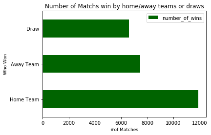

```python
wins_match = read_table("""
SELECT most_wins, count(*) AS number_of_wins
  FROM
(SELECT mt.id AS match_id, mt.season AS season, lg.name AS league_name, tm1.team_long_name AS home_team, tm2.team_long_name AS away_team,
   mt.home_team_goal AS home_team_goal, mt.away_team_goal AS away_team_goal,
   CASE
           WHEN mt.home_team_goal > mt.away_team_goal
               THEN 'Home Team'
   WHEN mt.away_team_goal > mt.home_team_goal
               THEN 'Away Team'
           ELSE 'Draw'
       END most_wins
  FROM country ct,
   league lg,
   Match mt,
   Team tm1,
   Team tm2
    ON mt.country_id = ct.id AND mt.league_id = lg.id AND mt.home_team_api_id = tm1.team_api_id AND mt.away_team_api_id = tm2.team_api_id
 ORDER BY match_id)
 GROUP BY most_wins
 ORDER BY number_of_wins DESC

""")

plt.figure()
wins_match.plot.barh(x='most_wins', y='number_of_wins', color='darkgreen');
plt.xlabel('#of Matches', fontsize=9)
plt.ylabel('Who Won', fontsize=9)
plt.title('Number of Matchs win by home/away teams or draws',fontsize=12)
plt.show()
```

From the chart we can see clearly that home team wins most matches

#### # of wins for Home Teams per season per league

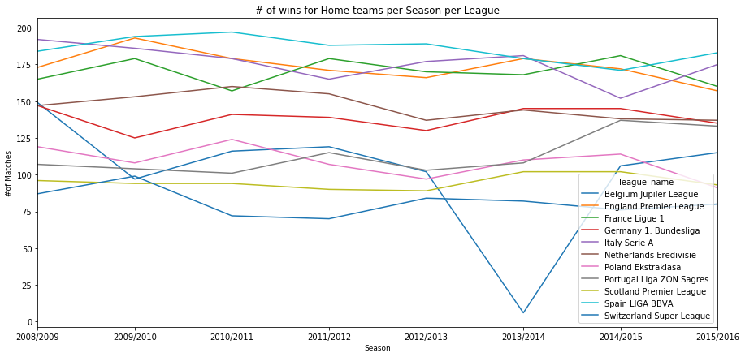

```python
wt = read_table("""
SELECT season, league_name, most_wins, count(*) AS total
  FROM
(SELECT mt.id AS match_id, mt.season AS season, lg.name AS league_name, tm1.team_long_name AS home_team, tm2.team_long_name AS away_team,
   mt.home_team_goal AS home_team_goal, mt.away_team_goal AS away_team_goal,
   CASE
           WHEN mt.home_team_goal > mt.away_team_goal
               THEN 'Home Team'
   WHEN mt.away_team_goal > mt.home_team_goal
               THEN 'Away Team'
           ELSE 'Draw'
       END most_wins
  FROM country ct,
   league lg,
   Match mt,
   Team tm1,
   Team tm2
    ON mt.country_id = ct.id AND mt.league_id = lg.id AND mt.home_team_api_id = tm1.team_api_id AND mt.away_team_api_id = tm2.team_api_id
 ORDER BY match_id)
 WHERE most_wins = 'Home Team'
 GROUP BY season, league_name, most_wins
 ORDER BY season, league_name DESC

 """)

wt
fig, ax = plt.subplots(figsize=(15,7))
wt.groupby(['season','league_name']).sum()['total'].unstack().plot(ax=ax)
plt.xlabel('Season', fontsize=9)
plt.ylabel('#of Matches', fontsize=9)
plt.title('# of wins for Home teams per Season per League',fontsize=12)
plt.show()
```

#### # of wins per team

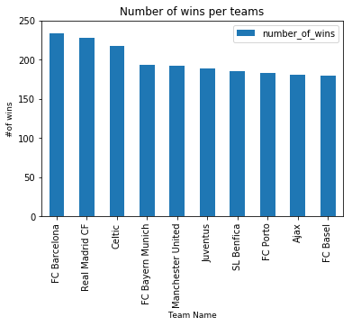

```python
wins_teams = read_table("""
SELECT most_wins, count(*) AS number_of_wins
  FROM
(SELECT mt.id AS match_id, mt.season AS season, lg.name AS league_name, tm1.team_long_name AS home_team, tm2.team_long_name AS away_team,
   mt.home_team_goal AS home_team_goal, mt.away_team_goal AS away_team_goal,
   CASE
           WHEN mt.home_team_goal > mt.away_team_goal
               THEN tm1.team_long_name
   WHEN mt.away_team_goal > mt.home_team_goal
               THEN tm2.team_long_name
           ELSE 'Draw'
       END most_wins
  FROM country ct,
   league lg,
   Match mt,
   Team tm1,
   Team tm2
    ON mt.country_id = ct.id AND mt.league_id = lg.id AND mt.home_team_api_id = tm1.team_api_id AND mt.away_team_api_id = tm2.team_api_id
 ORDER BY match_id)
 WHERE most_wins!='Draw'
 GROUP BY most_wins
 ORDER BY number_of_wins DESC
 LIMIT 10
 """)

plt.figure()
wins_teams.plot.bar(x='most_wins', y='number_of_wins', yticks = range(0,300,50));
plt.xlabel('Team Name', fontsize=9)
plt.ylabel('#of wins', fontsize=9)
plt.title('Number of wins per teams',fontsize=12)
plt.show()
```

FC Barccelona wins games more than any other team

#### Which team improved over years

In the following two statistics will show which teams improved/weaken between first and last season by comapring the number of wins

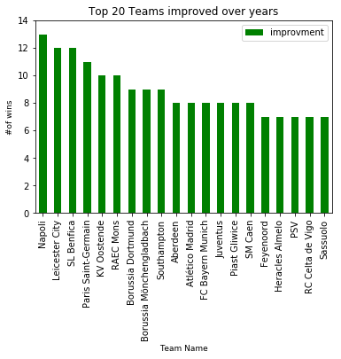

```python
#Improved Teams
improved = read_table("""SELECT t1.most_wins AS team_name, (t2.number_of_wins-t1.number_of_wins) AS improvment
  FROM (SELECT min(season) AS first_season,  most_wins, number_of_wins
  FROM
(SELECT season, most_wins, count(*) AS number_of_wins
  FROM
(SELECT mt.id AS match_id, mt.season AS season, lg.name AS league_name, tm1.team_long_name AS home_team, tm2.team_long_name AS away_team,
	   mt.home_team_goal AS home_team_goal, mt.away_team_goal AS away_team_goal,
	   CASE
           WHEN mt.home_team_goal > mt.away_team_goal
               THEN tm1.team_long_name
		   WHEN mt.away_team_goal > mt.home_team_goal
               THEN tm2.team_long_name
           ELSE 'Draw'
       END most_wins
  FROM country ct,
   league lg,
   Match mt,
   Team tm1,
   Team tm2
    ON mt.country_id = ct.id AND mt.league_id = lg.id AND mt.home_team_api_id = tm1.team_api_id AND mt.away_team_api_id = tm2.team_api_id
 ORDER BY match_id)
 WHERE most_wins!='Draw'
 GROUP BY season, most_wins
 ORDER BY most_wins, season)
 GROUP BY most_wins)t1,
 (SELECT max(season) AS last_season,  most_wins, number_of_wins
  FROM
(SELECT season, most_wins, count(*) AS number_of_wins
  FROM
(SELECT mt.id AS match_id, mt.season AS season, lg.name AS league_name, tm1.team_long_name AS home_team, tm2.team_long_name AS away_team,
	   mt.home_team_goal AS home_team_goal, mt.away_team_goal AS away_team_goal,
	   CASE
           WHEN mt.home_team_goal > mt.away_team_goal
               THEN tm1.team_long_name
		   WHEN mt.away_team_goal > mt.home_team_goal
               THEN tm2.team_long_name
           ELSE 'Draw'
       END most_wins
  FROM country ct,
   league lg,
   Match mt,
   Team tm1,
   Team tm2
    ON mt.country_id = ct.id AND mt.league_id = lg.id AND mt.home_team_api_id = tm1.team_api_id AND mt.away_team_api_id = tm2.team_api_id
 ORDER BY match_id)
 WHERE most_wins!='Draw'
 GROUP BY season, most_wins
 ORDER BY most_wins, season)
 GROUP BY most_wins
 ORDER BY most_wins)t2
 WHERE t1.most_wins=t2.most_wins
 ORDER BY improvment DESC
 LIMIT 20""")

plt.figure()
improved.plot.bar(x='team_name', y='improvment', yticks = range(0, 15, 2), color='green');
plt.xlabel('Team Name', fontsize=9)
plt.ylabel('#of wins', fontsize=9)
plt.title('Top 20 Teams improved over years',fontsize=12)
plt.show()
```

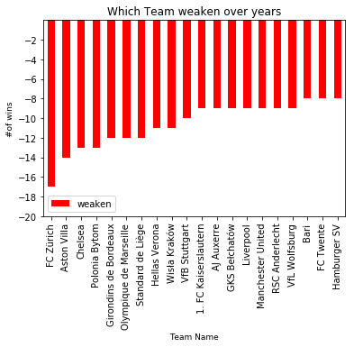

```python
#Weaken Teams
weaken = read_table("""SELECT t1.most_wins AS team_name, (t2.number_of_wins-t1.number_of_wins) AS weaken
  FROM (SELECT min(season) AS first_season,  most_wins, number_of_wins
  FROM
(SELECT season, most_wins, count(*) AS number_of_wins
  FROM
(SELECT mt.id AS match_id, mt.season AS season, lg.name AS league_name, tm1.team_long_name AS home_team, tm2.team_long_name AS away_team,
	   mt.home_team_goal AS home_team_goal, mt.away_team_goal AS away_team_goal,
	   CASE
           WHEN mt.home_team_goal > mt.away_team_goal
               THEN tm1.team_long_name
		   WHEN mt.away_team_goal > mt.home_team_goal
               THEN tm2.team_long_name
           ELSE 'Draw'
       END most_wins
  FROM country ct,
   league lg,
   Match mt,
   Team tm1,
   Team tm2
    ON mt.country_id = ct.id AND mt.league_id = lg.id AND mt.home_team_api_id = tm1.team_api_id AND mt.away_team_api_id = tm2.team_api_id
 ORDER BY match_id)
 WHERE most_wins!='Draw'
 GROUP BY season, most_wins
 ORDER BY most_wins, season)
 GROUP BY most_wins)t1,
 (SELECT max(season) AS last_season,  most_wins, number_of_wins
  FROM
(SELECT season, most_wins, count(*) AS number_of_wins
  FROM
(SELECT mt.id AS match_id, mt.season AS season, lg.name AS league_name, tm1.team_long_name AS home_team, tm2.team_long_name AS away_team,
	   mt.home_team_goal AS home_team_goal, mt.away_team_goal AS away_team_goal,
	   CASE
           WHEN mt.home_team_goal > mt.away_team_goal
               THEN tm1.team_long_name
		   WHEN mt.away_team_goal > mt.home_team_goal
               THEN tm2.team_long_name
           ELSE 'Draw'
       END most_wins
  FROM country ct,
   league lg,
   Match mt,
   Team tm1,
   Team tm2
    ON mt.country_id = ct.id AND mt.league_id = lg.id AND mt.home_team_api_id = tm1.team_api_id AND mt.away_team_api_id = tm2.team_api_id
 ORDER BY match_id)
 WHERE most_wins!='Draw'
 GROUP BY season, most_wins
 ORDER BY most_wins, season)
 GROUP BY most_wins
 ORDER BY most_wins)t2
 WHERE t1.most_wins=t2.most_wins
 ORDER BY weaken
 LIMIT 20""")

plt.figure()
weaken.plot.bar(x='team_name', y='weaken', yticks = range(-20, 0, 2), color='red');
plt.xlabel('Team Name', fontsize=9)
plt.ylabel('#of wins', fontsize=9)
plt.title('Which Team weaken over years',fontsize=12)
plt.show()
```

## Conclusions

- date columns in match, player_attributes and teams_attributes tables were changed from object to datetime. Also, birtday column in player table.
- some findings on statistics:
  - Most players use right feet
  - home team wins more mates and score more
  - FC Barclona wins the most games

### Limitation

- Team table doesn't link teams to its league. Thus, the database isn't complete and won't help to connect each team to its league. But from match table, I can retrive this information but will need more steps.
- Some leagues has missing matches records. Thus, any statistics regarding Belgium League matches won't be accurate.